# Sesión 5: Random Forests y exploración aleatorizada

Definimos primero unas librerías y funciones que vamos a usar a durante la sesión:

```python
%matplotlib inline
import matplotlib.pyplot as plt
import numpy as np
import pylab as pl
from sklearn.datasets import make_circles
from matplotlib.colors import Normalize
from time import time


# Función para visualizar un conjunto de datos en 2D
def plot_data(X, y):
    y_unique = np.unique(y)
    colors = pl.cm.rainbow(np.linspace(0.0, 1.0, y_unique.size))
    for this_y, color in zip(y_unique, colors):
        this_X = X[y == this_y]
        pl.scatter(this_X[:, 0], this_X[:, 1],  c=color,
                    alpha=0.5, edgecolor='k',
                    label="Class %s" % this_y)
    pl.legend(loc="best")
    pl.title("Data")

# Función para visualizar de la superficie de decisión de un clasificador
def plot_decision_region(X, pred_fun):
    min_x = np.min(X[:, 0])
    max_x = np.max(X[:, 0])
    min_y = np.min(X[:, 1])
    max_y = np.max(X[:, 1])
    min_x = min_x - (max_x - min_x) * 0.05
    max_x = max_x + (max_x - min_x) * 0.05
    min_y = min_y - (max_y - min_y) * 0.05
    max_y = max_y + (max_y - min_y) * 0.05
    x_vals = np.linspace(min_x, max_x, 100)
    y_vals = np.linspace(min_y, max_y, 100)
    XX, YY = np.meshgrid(x_vals, y_vals)
    grid_r, grid_c = XX.shape
    ZZ = np.zeros((grid_r, grid_c))
    for i in range(grid_r):
        for j in range(grid_c):
            ZZ[i, j] = pred_fun(XX[i, j], YY[i, j])
    pl.contourf(XX, YY, ZZ, 100, cmap = pl.cm.coolwarm, vmin= -1, vmax=2)
    pl.colorbar()
    pl.xlabel("x")
    pl.ylabel("y")

class MidpointNormalize(Normalize):

    def __init__(self, vmin=None, vmax=None, midpoint=None, clip=False):
        self.midpoint = midpoint
        Normalize.__init__(self, vmin, vmax, clip)

    def __call__(self, value, clip=None):
        x, y = [self.vmin, self.midpoint, self.vmax], [0, 0.5, 1]
        return np.ma.masked_array(np.interp(value, x, y))

def gen_pred_fun(clf):
    def pred_fun(x1, x2):
        x = np.array([[x1, x2]])
        return clf.predict(x)[0]
    return pred_fun

def plot_labels(n_folds, n_classes, list_labels):
    ind = np.arange(n_folds)
    width = 0.15

    countings = []
    for labels in list_labels:
        labels = np.array(labels)
        countings.append([np.count_nonzero(labels == x) for x in range(n_classes)])

    class_bars = []
    for cls in range(n_classes):
        class_bars.append([l[cls] for l in countings])

    fig, ax = pl.subplots()
    i = 0
    for class_bar in class_bars:
        ax.bar(ind + width*i, class_bar, width, label='Clase '+str(i))
        i += 1

    ax.set_xticks(ind + 2*width / 3)
    ax.set_xticklabels(['Pliegue {}'.format(k) for k in range(n_folds)])
    pl.legend(loc="best")
    pl.title("Etiquetas")
```

# Árboles de decisión y Bagging

Considere el siguiente conjunto de datos

```python
from sklearn.datasets import make_circles, make_moons
from sklearn.model_selection import train_test_split

np.random.seed(0)

X, y = make_circles(n_samples=1000, factor=.4, noise=.15)

X_train, X_test, y_train, y_test = train_test_split(X,
                                                    y,
                                                    test_size=0.4,
                                                    random_state=2)
```

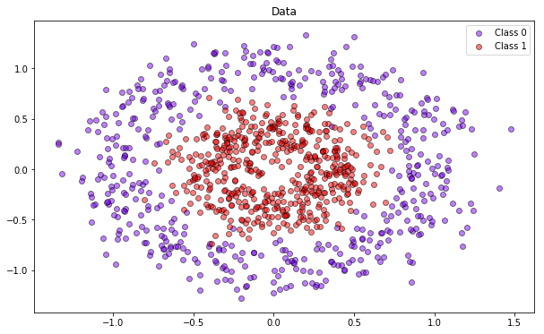

```python
pl.figure(figsize = (10, 6))
plot_data(X, y)
```

Vamos a entrenar un modelo de árbol de decisión para resolver este problema de clasificación.

```python
from sklearn.tree import DecisionTreeClassifier
```

Entrenamos un árbol de decisión de profundidad máxima $5$

```python
dt = DecisionTreeClassifier(max_depth=5)

dt.fit(X_train, y_train)
```

```
DecisionTreeClassifier(class_weight=None, criterion='gini', max_depth=5,
            max_features=None, max_leaf_nodes=None,
            min_impurity_decrease=0.0, min_impurity_split=None,
            min_samples_leaf=1, min_samples_split=2,
            min_weight_fraction_leaf=0.0, presort=False, random_state=None,
            splitter='best')
```

```
Error en entrenamiento: 0.021666666666666612
Error en prueba: 0.06000000000000005
```

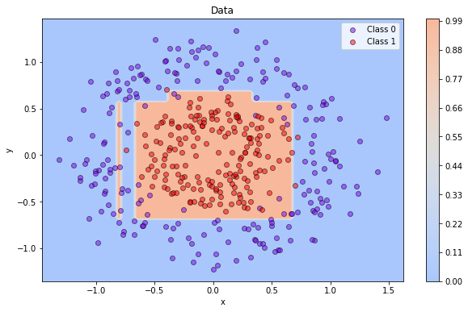

```python
print('Error en entrenamiento: {}'.format(1-dt.score(X_train, y_train)))
print('Error en prueba: {}'.format(1-dt.score(X_test, y_test)))

pl.figure(figsize = (10, 6))
plot_decision_region(X_test, gen_pred_fun(dt))
plot_data(X_test, y_test)
```

El modelo presenta un error de generalización del $6\%$, además sus predicciones no se ajustan a la naturaleza de los datos

Problemas:

- En algunos casos, las franteras de decisión generadas por el árbol de decisión (paralelas a los ejes) no son lo suficientemente flexibles para capturar la no linealidad del conjunto de datos.
- Por otro lado, los árboles de clasificación pueden crear reglas decisión muy espcíficas que se ajustan demasiado a los datos de entrenamiento.
- Tambien son sensibles a pequeñas variaciones de los datos que pueden resultar en árboles totalmente distintos. Esto es un problema cuando se hace validación cruzada de k-pliegues.

**¿Cómo solucionar este problema?**

Vamos a utilizar una estrategia conocida como *clasificación por comité* o *ensamble de clasificadores*. Un ensamble de clasificadores combina diferentes algoritmos de aprendizaje para obtener un mejor desempeño predictivo. A continuación, presentamos una forma de como construír un ensamble de árboles de clasificación. Se entrenan diferentes árboles en diferentes subconjuntos de los datos de entrenamiento. Posteriormente cuando se va hacer una predicción para un nuevo dato, se obtienen las predicciones de todos los árboles y se regresa aquella clase de mayor frecuencia predicha.

[figure not shown]

A la técnica de la figura se le conoce como *bagging*. En el ejemplo siguiente vamos a utilizar la función `BaggingClassifier` la cual entrena un modelo usando esta estrategia. Los parámetros recibidos por la función son los siguientes:

- `base_estimator`: Consiste en el estimador base que se va a entrenar sobre los diferentes subconjunto del conjunto de datos de entrenamiento.
- `n_estimators`: Es el número de estimadores base que se van a usar para la estrategia de *bagging*.

```
Error en entrenamiento: 0.013333333333333308
Error en prueba: 0.040000000000000036
```

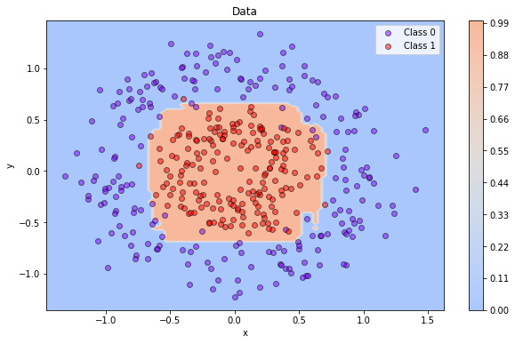

```python
from sklearn.ensemble import BaggingClassifier

bc = BaggingClassifier(base_estimator=DecisionTreeClassifier(max_depth=5), n_estimators=20)
bc.fit(X_train, y_train)

print('Error en entrenamiento: {}'.format(1-bc.score(X_train, y_train)))
print('Error en prueba: {}'.format(1-bc.score(X_test, y_test)))

pl.figure(figsize = (10, 6))
plot_decision_region(X_test, gen_pred_fun(bc))
plot_data(X_test, y_test)
```

# Random Forests

Existen varias alternativas para combinar y promediar árboles de decisión, una de las más usadas es Random Forest. Scikit-Learn provee una implementación a través de `sklearn.ensemble.RandomForestClassifier`. Más adelante se discuten los parámetros más importantes de esta implementación.

```python
from sklearn.ensemble import RandomForestClassifier
```

```python
rf = RandomForestClassifier(n_estimators=14, max_depth=5)

rf.fit(X_train, y_train)
```

```
RandomForestClassifier(bootstrap=True, class_weight=None, criterion='gini',
            max_depth=5, max_features='auto', max_leaf_nodes=None,
            min_impurity_decrease=0.0, min_impurity_split=None,
            min_samples_leaf=1, min_samples_split=2,
            min_weight_fraction_leaf=0.0, n_estimators=14, n_jobs=1,
            oob_score=False, random_state=None, verbose=0,
            warm_start=False)
```

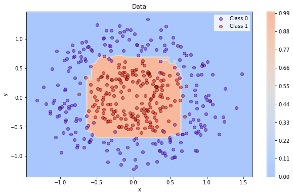

```python
pl.figure(figsize = (10, 6))
plot_decision_region(X_test, gen_pred_fun(rf))
plot_data(X_test, y_test)
```

```python
print('Error en entrenamiento: {}'.format(1-rf.score(X_train, y_train)))
print('Error en prueba: {}'.format(1-rf.score(X_test, y_test)))
```

```
Error en entrenamiento: 0.015000000000000013
Error en prueba: 0.05249999999999999
```

Mientras baja el error de generalización, observamos tambien que se adapta mejor a la naturaleza de los datos

## Intuición detrás de RandomForests

Random Forest es una técnica de **ensamble** que combina diferentes árboles de decisión. Estos árboles se entrenan en diferentes muestras del conjunto de datos, estos árboles pueden sobreajustarse, sin embargo la combinación de sus predicciones resulta en un clasificador con menor sobreajuste. Para entender la idea de como se construye este algoritmo, suponga que entrenamos los siguientes árboles para determinar si una persona está enferma o sana:

[figure not shown]

**¿Qué sucede si todos los árboles de clasificación son iguales?**

**¿Cómo logro que cada árbol de clasificación sea diferente?**

## Algoritmo básico Random Forest

A diferencia del árbol común de decisión, los árboles de Random Forest se entrenan de una forma diferente. A continuación, presentamos el algoritmo básico de entrenamiento:

1. Para cada árbol se realiza el siguiente procedimiento:
   - Se escoge una muestra con reemplazo de tamaño $n$ del conjunto de entrenamiento.
   - Se seleccionan $m$ variables al azar de las variables disponibles
   - Se entrena un árbol sobre la muestra usando las $m$ variables repitiendo los siguientes pasos:
     - Se escoge la variable (y umbral) que genera la mejor partición
     - Se divide los datos en dos subconjuntos de acuerdo a la variable y el umbral
     - Si no se satisface un criterio de parada se aplica este procedimiento recursivamente sobre los subconjutos
2. Una vez cada árbol ha sido entrenado, se genera el ensamble de árboles.

## Implementación en Scikit-Learn

La implementación en Scikit-Learn nos permite controlar los siguientes parámetros:

- `n_estimators`: Número de árboles a entrenar
- `max_features`: Número de variables $m$ al azar que se tienen en cuenta para la construcción de cada árbol.

Un número grande de árboles resulta en un buen desempeño a costas del costo computacional. Ambos parámetros deben ser explorados usando validación cruzada. A continuación, usaremos el conjunto de datos `wine`.

```python
import pandas as pd

df = pd.read_csv('winedata.txt')
```

```python
df.head()
```

|  | Class | Alcohol | Malic_acid | Ash | Alcalinity | Magnesium | Phenols | Flavanoids | Nonflavanoid | Proanthocyanins | Color | Hue | OD280/OD315 | Proline |
| --- | --- | --- | --- | --- | --- | --- | --- | --- | --- | --- | --- | --- | --- | --- |
| 0 | 1 | 14.23 | 1.71 | 2.43 | 15.6 | 127 | 2.80 | 3.06 | 0.28 | 2.29 | 5.64 | 1.04 | 3.92 | 1065 |
| 1 | 1 | 13.20 | 1.78 | 2.14 | 11.2 | 100 | 2.65 | 2.76 | 0.26 | 1.28 | 4.38 | 1.05 | 3.40 | 1050 |
| 2 | 1 | 13.16 | 2.36 | 2.67 | 18.6 | 101 | 2.80 | 3.24 | 0.30 | 2.81 | 5.68 | 1.03 | 3.17 | 1185 |
| 3 | 1 | 14.37 | 1.95 | 2.50 | 16.8 | 113 | 3.85 | 3.49 | 0.24 | 2.18 | 7.80 | 0.86 | 3.45 | 1480 |
| 4 | 1 | 13.24 | 2.59 | 2.87 | 21.0 | 118 | 2.80 | 2.69 | 0.39 | 1.82 | 4.32 | 1.04 | 2.93 | 735 |

Generamos la matriz de características y el arreglo de etiquetas

```python
X = df.drop(columns=['Class'], axis=1).values
y = df['Class'].values
y
```

```
array([1, 1, 1, 1, 1, 1, 1, 1, 1, 1, 1, 1, 1, 1, 1, 1, 1, 1, 1, 1, 1, 1,
       1, 1, 1, 1, 1, 1, 1, 1, 1, 1, 1, 1, 1, 1, 1, 1, 1, 1, 1, 1, 1, 1,
       1, 1, 1, 1, 1, 1, 1, 1, 1, 1, 1, 1, 1, 1, 1, 2, 2, 2, 2, 2, 2, 2,
       2, 2, 2, 2, 2, 2, 2, 2, 2, 2, 2, 2, 2, 2, 2, 2, 2, 2, 2, 2, 2, 2,
       2, 2, 2, 2, 2, 2, 2, 2, 2, 2, 2, 2, 2, 2, 2, 2, 2, 2, 2, 2, 2, 2,
       2, 2, 2, 2, 2, 2, 2, 2, 2, 2, 2, 2, 2, 2, 2, 2, 2, 2, 2, 2, 3, 3,
       3, 3, 3, 3, 3, 3, 3, 3, 3, 3, 3, 3, 3, 3, 3, 3, 3, 3, 3, 3, 3, 3,
       3, 3, 3, 3, 3, 3, 3, 3, 3, 3, 3, 3, 3, 3, 3, 3, 3, 3, 3, 3, 3, 3,
       3, 3])
```

Definimos la malla de parámetros:

```python
max_features_params = [np.round(10**-1 * i, decimals=1) for i in range(1, 11, 1)]
param_grid = {'n_estimators': [2**i for i in range(2, 12, 1)], 'max_features': max_features_params}
```

```python
print('Número de árboles: {}'.format(param_grid['n_estimators']))
```

```
Número de árboles: [4, 8, 16, 32, 64, 128, 256, 512, 1024, 2048]
```

```python
print('Porcentaje de características a usar: {}'.format(param_grid['max_features']))
```

```
Porcentaje de características a usar: [0.1, 0.2, 0.3, 0.4, 0.5, 0.6, 0.7, 0.8, 0.9, 1.0]
```

Creamos la partición de entrenamiento y prueba

```python
from sklearn.model_selection import GridSearchCV, train_test_split

X_train, X_test, y_train, y_test = train_test_split(X, y, test_size=0.3, random_state=1, stratify=y)
```

Corremos el modelo `GridSearchCV` usando la retícula de parámetros

```python
start = time()
clf = GridSearchCV(RandomForestClassifier(), param_grid=param_grid, verbose=1, n_jobs=-1, cv=5)
clf.fit(X_train, y_train)
print("GridSearchCV tomó {} segundos usando {} configuraciones".format(time() - start,
                                                                         len(clf.cv_results_['params'])))
```

```
Fitting 5 folds for each of 100 candidates, totalling 500 fits
```

```
[Parallel(n_jobs=-1)]: Done 313 tasks      | elapsed:   28.0s
```

```
GridSearchCV tomó 54.01153326034546 segundos usando 100 configuraciones
```

```
[Parallel(n_jobs=-1)]: Done 500 out of 500 | elapsed:   53.7s finished
```

Usando `cv_results_` extraemos el desempeño promedio sobre cada configuración de parámetros

```python
scores = clf.cv_results_['mean_test_score'].reshape(len(param_grid['max_features']),
                                                    len(param_grid['n_estimators']))
```

```python
scores
```

```
array([[0.93548387, 0.91935484, 0.95967742, 0.97580645, 0.98387097,
        0.98387097, 0.98387097, 0.98387097, 0.98387097, 0.98387097],
       [0.92741935, 0.94354839, 0.98387097, 0.98387097, 0.98387097,
        0.98387097, 0.97580645, 0.98387097, 0.97580645, 0.98387097],
       [0.92741935, 0.98387097, 0.97580645, 0.97580645, 0.97580645,
        0.97580645, 0.97580645, 0.97580645, 0.97580645, 0.97580645],
       [0.92741935, 0.93548387, 0.95967742, 0.96774194, 0.97580645,
        0.97580645, 0.97580645, 0.97580645, 0.97580645, 0.97580645],
       [0.93548387, 0.96774194, 0.95967742, 0.96774194, 0.96774194,
        0.96774194, 0.97580645, 0.97580645, 0.97580645, 0.97580645],
       [0.92741935, 0.95967742, 0.95967742, 0.97580645, 0.97580645,
        0.97580645, 0.97580645, 0.97580645, 0.97580645, 0.97580645],
       [0.91129032, 0.9516129 , 0.95967742, 0.96774194, 0.96774194,
        0.96774194, 0.96774194, 0.97580645, 0.97580645, 0.97580645],
       [0.9516129 , 0.93548387, 0.94354839, 0.96774194, 0.97580645,
        0.96774194, 0.97580645, 0.97580645, 0.97580645, 0.97580645],
       [0.93548387, 0.96774194, 0.96774194, 0.96774194, 0.97580645,
        0.96774194, 0.96774194, 0.96774194, 0.97580645, 0.96774194],
       [0.91129032, 0.94354839, 0.95967742, 0.94354839, 0.95967742,
        0.95967742, 0.95967742, 0.95967742, 0.95967742, 0.95967742]])
```

Visualizamos la mejor combinación de parámetros:

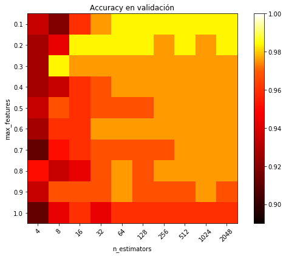

```python
pl.figure(figsize=(10, 6))
pl.subplots_adjust(left=.2, right=0.95, bottom=0.15, top=0.95)
pl.imshow(scores, interpolation='nearest', cmap=plt.cm.hot,
           norm=MidpointNormalize(vmin=0.89, midpoint=0.97, vmax=1.))
pl.xlabel('n_estimators')
pl.ylabel('max_features')
pl.colorbar()
pl.xticks(np.arange(len(param_grid['n_estimators'])), param_grid['n_estimators'], rotation=45)
pl.yticks(np.arange(len(param_grid['max_features'])), param_grid['max_features'])
pl.title('Accuracy en validación')
pl.show() # Entre más arboles mejor, entre menos características mejor (10% que para el conjunto de datos wine es 1 o 2 vars)
```

La mejor combinación de parámetros está dada por:

```python
clf.best_params_
```

```
{'max_features': 0.1, 'n_estimators': 64}
```

```python
clf.best_score_
```

```
0.9838709677419355
```

Finalmente, reportamos en el conjunto de prueba:

```python
clf.score(X_test, y_test)
```

```
1.0
```

## Importancia de características

Una ventaja muy significativa de usar Random Forests consiste en la posibilidad de obtener la importancia de las características del conjunto de datos. Esta importancia nos indica qué tanto una característica contribuye al desempeño en los nodos de los diferentes árboles.

A continuación, seguimos usando el conjunto de datos `wine` y obtenemos la importancia de las características del mejor modelo usando validación cruzada. Entrenemos de nuevo el modelo:

```python
clf = RandomForestClassifier(n_estimators=64, max_features=.1)

clf.fit(X_train, y_train);
```

Extraemos la importancia de las características

```python
clf.feature_importances_
```

```
array([0.12501515, 0.0692023 , 0.04384025, 0.07453953, 0.05741117,
       0.07197751, 0.07658201, 0.03417012, 0.05802869, 0.1104047 ,
       0.06747811, 0.10632191, 0.10502857])
```

A continuación ordenamos las características por su importancia

```python
importances = clf.feature_importances_
indices = np.argsort(importances)[::-1]

print("Importancia de características:")

for f in range(X_train.shape[1]):
    print("Característica %s (%f)" % (df.columns[int(1+indices[f])], importances[indices[f]]))
```

```
Importancia de características:
Característica Alcohol (0.125015)
Característica Color (0.110405)
Característica OD280/OD315 (0.106322)
Característica Proline (0.105029)
Característica Flavanoids (0.076582)
Característica Alcalinity (0.074540)
Característica Phenols (0.071978)
Característica Malic_acid (0.069202)
Característica Hue (0.067478)
Característica Proanthocyanins (0.058029)
Característica Magnesium (0.057411)
Característica Ash (0.043840)
Característica Nonflavanoid (0.034170)
```

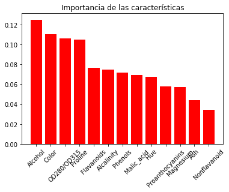

```python
plt.figure()
plt.title("Importancia de las características")
plt.bar(range(X_train.shape[1]), importances[indices],
       color="r", align="center")
xticks_labels = [df.columns[1+i] for i in indices]
plt.xticks(range(X.shape[1]), xticks_labels, rotation=45)
plt.xlim([-1, X.shape[1]])
plt.show()
```

# Optimización aleatoria de parámetros

A pesar de las ventajas que ofrece `GridSearchCV` sobre la exploración sistemática de los hiperparámetros de un modelo, puede gastar un tiempo considerable en esta exploración. Scikit-Learn permite hacer también una exploración aleatoria de los parámetros, la cual se ha demostrado empiricamente que es más eficiente que optimizar los parámetros usando una malla con `GridSearchCV` ([Referencia](http://www.jmlr.org/papers/volume13/bergstra12a/bergstra12a.pdf)). `RandomizedSearchCV` implementa una búsqueda aleatoria sobre los parámetros. El rango de exploración de los parámetros se puede especificar de la siguiente manera:

`RandomizedSearchCV` puede recibir tanto listas de elementos como distribuciones de probabilidad, las cuales deben ser especificadas usando `scipy.stats`. A continuación, creamos nuestro estimador y definimos la distribución de parámetros:

```python
from sklearn.model_selection import RandomizedSearchCV
from scipy.stats import uniform
from scipy.stats import randint

clf = RandomForestClassifier()

param_dist = {"n_estimators": randint(4, 800),
              "max_features": uniform()} # núm aleatorio entre 0 y 1
```

`n_iter_search` nos define el número de configuraciones que vamos a extraer de la distribución de parámetros.

```python
n_iter_search = 20
random_search = RandomizedSearchCV(clf, param_distributions=param_dist,
                                   n_iter=n_iter_search, cv=5, # 5 folds
                                   n_jobs=-1, verbose=2) # n_jobs paralelizar
```

`RandomizedSearchCV` también soporta la ejecución en paralelo usando `n_jobs=-1`. También podemos especificar el número de pliegues a usar usando `cv=5`

```python
start = time()
random_search.fit(X_train, y_train)
print("RandomizedSearchCV tomó {} segundos usando {} configuraciones".format(time() - start,
                                                                               n_iter_search))
```

[output not shown]

```
[Parallel(n_jobs=-1)]: Done  25 tasks      | elapsed:    2.4s
```

[output not shown]

[output cut: 87 more lines]

[output not shown]

```
[Parallel(n_jobs=-1)]: Done 100 out of 100 | elapsed:   11.5s finished
```

```
RandomizedSearchCV tomó 12.179044723510742 segundos usando 20 configuraciones
```

Extraemos los resultados con mejor desempeño promedio:

```python
cv_results = pd.DataFrame(random_search.cv_results_)

cv_results = cv_results[['param_n_estimators', 'param_max_features', 'mean_test_score']]
cv_results.sort_values(by='mean_test_score', ascending=False).head()
```

|  | param_n_estimators | param_max_features | mean_test_score |
| --- | --- | --- | --- |
| 15 | 720 | 0.00818729 | 0.983871 |
| 5 | 622 | 0.0841543 | 0.983871 |
| 12 | 755 | 0.00091292 | 0.983871 |
| 17 | 224 | 0.0294352 | 0.983871 |
| 9 | 652 | 0.0437978 | 0.983871 |

Verificamos la mejor configuración y su puntaje sobre todas las particiones de validación:

```python
random_search.best_params_
```

```
{'max_features': 0.08415431203200696, 'n_estimators': 622}
```

```python
random_search.best_score_
```

```
0.9838709677419355
```

Reportamos el error de generalización:

```python
random_search.score(X_test, y_test)
```

```
1.0
```

# Taller

Este taller se va a enfocar en trabajar con el conjunto de datos del censo de 1993 de USA. El conjunto de datos reune una serie de características socioeconómicas tanto categóricas como numéricas. El objetivo es construir un clasificador que determine si la persona tiene una ganancia alta al año (más de 50K USD) o baja (menos de 50K USD al año). A continuación encuentra una descripción de las características:

Etiqueta:

- income: >50K, <=50K. Características:
- age: Variable continua.
- workclass: Private, Self-emp-not-inc, Self-emp-inc, Federal-gov, Local-gov, State-gov, Without-pay, Never-worked.
- fnlwgt: Variable continua.
- education: Bachelors, Some-college, 11th, HS-grad, Prof-school, Assoc-acdm, Assoc-voc, 9th, 7th-8th, 12th, Masters, 1st-4th, 10th, Doctorate, 5th-6th, Preschool.
- education-num: Variable continua.
- marital-status: Married-civ-spouse, Divorced, Never-married, Separated, Widowed, Married-spouse-absent, Married-AF-spouse.
- occupation: Tech-support, Craft-repair, Other-service, Sales, Exec-managerial, Prof-specialty, Handlers-cleaners, Machine-op-inspct, Adm-clerical, Farming-fishing, Transport-moving, Priv-house-serv, Protective-serv, Armed-Forces.
- relationship: Wife, Own-child, Husband, Not-in-family, Other-relative, Unmarried.
- race: White, Asian-Pac-Islander, Amer-Indian-Eskimo, Other, Black.
- sex: Female, Male.
- capital-gain: Variable continua.
- capital-loss: Variable continua.
- hours-per-week: Variable continua.
- native-country: United-States, Cambodia, England, Puerto-Rico, Canada, Germany, Outlying-US(Guam-USVI-etc), India, Japan, Greece, South, China, Cuba, Iran, Honduras, Philippines, Italy, Poland, Jamaica, Vietnam, Mexico, Portugal, Ireland, France, Dominican-Republic, Laos, Ecuador, Taiwan, Haiti, Columbia, Hungary, Guatemala, Nicaragua, Scotland, Thailand, Yugoslavia, El-Salvador, Trinadad&Tobago, Peru, Hong, Holand-Netherlands.

## Carga de datos

- Cargue el conjunto de datos `adult.csv` en Pandas.
- Este conjunto de datos tiene dos problemas:
  - Contiene datos faltantes, representados por un interrogante: "?"
  - Es un conjunto de datos imbalanceado.
- Para verificar ambos hechos:
  - Verifique qué porcentaje de valores indefinidos hay para las variables `workclass`, `occupation` y `native-country`.
  - Luego, puede limpiar aquellas filas que contengan datos indefinidos. Puede usar el siguiente código:

    ```
    df = df[df["workclass"] != "?"]
    df = df[df["occupation"] != "?"]
    df = df[df["native-country"] != "?"]
    ```

  - Verifique el DataFrame tenga un tamaño de 45222 elementos por 15 características.
  - Verifique la distribución de etiquetas en la columna `income`, ¿Cuál clase tiene mayor número de ejemplos?
- Use `.describe()` para obtener un análisis de las variables numéricas del conjunto de datos.
- Realice un conteo de cada elemento de las variables categóricas:
  - ['workclass', 'race', 'education','marital-status', 'occupation','relationship', 'gender', 'native-country', 'income']
- Simplifique la categoría 'marital-status' de la siguiente forma:
  - 'Divorced' -> 'not married'
  - 'Married-AF-spouse' -> 'married'
  - 'Married-civ-spouse' -> 'married'
  - 'Married-spouse-absent' -> 'married'
  - 'Never-married' -> 'not married'
  - 'Separated' -> 'not married'
  - 'Widowed' -> 'not married'
- Convierta las variables categóricas a numéricas. El enfoque aquí presentado no es el mejor, pero será una primera aproximación. Puede usar el siguiente código:

  ```
  for col in category_col:
    b, c = np.unique(df[col], return_inverse=True)
    df[col] = c
  ```

  A pesar de que no queremos inducir un orden en las categorías analizadas, es un buen inicio para probar Validación cruzada.
- Cree una matriz `X` de características usando:
  - ['age','workclass','education','educational-num','marital-status', 'occupation','relationship','race','gender','capital-gain','capital-loss','hours-per-week', 'native-country']
- Cree el arreglo `y` usando la columna `income`:
- Genere una partición de entrenamiento y prueba $80\%-20\%$ estratificada. NO MODIFIQUE EL CONJUNTO DE DATOS ORIGINAL.
- Verifique que en efecto la partición haya sido estratificada.

## RandomizedSearchCV

- Genere la siguiente distribución de parámetros:
  - `n_estimators` seguirá una distribución uniforme discreta entre 4 y 512
  - `max_features` seguirá una distribución uniforme entre 0 y 1
  - `max_depth` será un valor entre 5 o None
  - `bootstrap` será un valor entre True o False
- ¿Qué hace `max_depth` y `bootstrap`? ¿Qué significa que `max_depth` sea None? Consulte la [documentación](http://scikit-learn.org/stable/modules/generated/sklearn.ensemble.RandomForestClassifier.html)
- Entrene un RandomForestClassifier sobre las siguientes condiciones:
  - 20 iteraciones de la distribución de parámetros
  - Pliegues de la validación cruzada= 5
  - Use `n_jobs=-1` para hacer la búsqueda de parámetros de forma paralela
- ¿Cuales son las mejores configuraciones?
- ¿Qué desempeño tienen las mejores configuraciones?
- Reporte accuracy, precision, recall y matriz de confusión en el conjunto de prueba

```python
##Cargue el conjunto de datos adult.csv en Pandas.

df  = pd.read_csv('adult.csv')

## Este conjunto de datos tiene dos problemas:
## Contiene datos faltantes, representados por un interrogante: "?"
## Es un conjunto de datos imbalanceado.
## Para verificar ambos hechos:
## Verifique qué porcentaje de valores indefinidos hay para las variables workclass, occupation y native-country.


#df[(df['workclass'] == '?')].shape[0]/ df.shape[0]*100
#df[(df['occupation'] == '?')].shape[0]/ df.shape[0]*100
#df[(df['native-country'] == '?')].shape[0]/ df.shape[0]*100

print('Porcentaje de valores indefinidos en las variables:')

print('Native Country:{}%'.format(df[(df['workclass'] == '?')].shape[0]/ df.shape[0]*100))
print('Native Country:{}%'.format(df[(df['occupation'] == '?')].shape[0]/ df.shape[0]*100))
print('Native Country:{}%'.format(df[(df['native-country'] == '?')].shape[0]/ df.shape[0]*100))

# df[(df['workclass'] == '?') | (df['occupation'] == '?') | (df['native-country'] == '?')].shape[0]
## Luego, puede limpiar aquellas filas que contengan datos indefinidos. Puede usar el siguiente código:

df = df[df["workclass"] != "?"]
df = df[df["occupation"] != "?"]
df = df[df["native-country"] != "?"]

##  Verifique el DataFrame tenga un tamaño de 45222 elementos por 15 características.

df.shape
```

```
Porcentaje de valores indefinidos en las variables:
Native Country:5.7307235575938735%
Native Country:5.751197739650301%
Native Country:1.7546374022357807%
```

```
(45222, 15)
```

```python
##  Verifique la distribución de etiquetas en la columna income, ¿Cuál clase tiene mayor número de ejemplos?

#df['income'].groupby('income').count()
print(df.groupby(['income'])['income'].count())

# Use .describe() para obtener un análisis de las variables numéricas del conjunto de datos.

df.describe()
```

```
income
<=50K    34014
>50K     11208
Name: income, dtype: int64
```

|  | age | fnlwgt | educational-num | capital-gain | capital-loss | hours-per-week |
| --- | --- | --- | --- | --- | --- | --- |
| count | 45222.000000 | 4.522200e+04 | 45222.000000 | 45222.000000 | 45222.000000 | 45222.000000 |
| mean | 38.547941 | 1.897347e+05 | 10.118460 | 1101.430344 | 88.595418 | 40.938017 |
| std | 13.217870 | 1.056392e+05 | 2.552881 | 7506.430084 | 404.956092 | 12.007508 |
| min | 17.000000 | 1.349200e+04 | 1.000000 | 0.000000 | 0.000000 | 1.000000 |
| 25% | 28.000000 | 1.173882e+05 | 9.000000 | 0.000000 | 0.000000 | 40.000000 |
| 50% | 37.000000 | 1.783160e+05 | 10.000000 | 0.000000 | 0.000000 | 40.000000 |
| 75% | 47.000000 | 2.379260e+05 | 13.000000 | 0.000000 | 0.000000 | 45.000000 |
| max | 90.000000 | 1.490400e+06 | 16.000000 | 99999.000000 | 4356.000000 | 99.000000 |

```python
#Realice un conteo de cada elemento de las variables categóricas:
# ['workclass', 'race', 'education','marital-status', 'occupation','relationship', 'gender', 'native-country', 'income']

#print(df.groupby(['workclass', 'race', 'education','marital-status', 'occupation','relationship', 'gender', 'native-country', 'income'])['income'].count())
#df[['workclass','race','education','marital-status', 'occupation','relationship', 'gender', 'native-country', 'income']].apply(lambda x: x.value_counts())
#df.loc[['workclass','race','education','marital-status', 'occupation','relationship', 'gender', 'native-country', 'income']]

category_col = ['workclass','race','education','marital-status', 'occupation','relationship', 'gender', 'native-country', 'income']

for col in category_col:
    print('Columna:{}'.format(col))
    print('Clases:{}'.format(df[col].value_counts()))
```

[output not shown]

[output cut: 98 more lines]

```python
#Simplifique la categoría 'marital-status' de la siguiente forma:
#       'Divorced' -> 'not married'
#        'Married-AF-spouse' -> 'married'
#        'Married-civ-spouse' -> 'married'
#        'Married-spouse-absent' -> 'married'
#        'Never-married' -> 'not married'
#        'Separated' -> 'not married'
#        'Widowed' -> 'not married'

df['ms'] = df['marital-status'].apply(lambda x: 'married' if ((x == 'Married-AF-spouse')| (x == 'Married-civ-spouse') |
                                                      (x == 'Married-spouse-absent')) else 'not married')
df['marital-status'] = df ['ms']
df.drop(['ms'],inplace = True,axis=1)
df.info()
```

[output not shown]

```python
# Convierta las variables categóricas a numéricas.

category_col = ['workclass','race','education','marital-status', 'occupation','relationship', 'gender', 'native-country', 'income']

# El enfoque aquí presentado no es el mejor, pero será una primera aproximación.
# Puede usar el siguiente código:

for col in category_col:
    b, c = np.unique(df[col], return_inverse=True)
    df[col] = c
```

[output not shown]

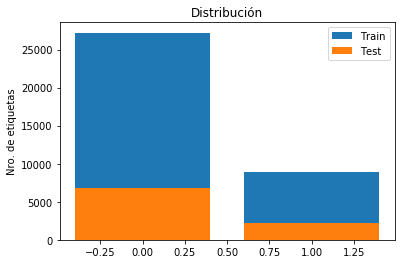

```python
# A pesar de que no queremos inducir un orden en las categorías analizadas, es un buen inicio para
# probar Validación cruzada.
# Cree una matriz X de características usando: ['age','workclass','education','educational-num','marital-status', 'occupation','relationship',
# 'race','gender','capital-gain','capital-loss','hours-per-week', 'native-country']

df1 = df.drop(['fnlwgt'], axis=1)
df1.info()

# Cree el arreglo y usando la columna income:
# Genere una partición de entrenamiento y prueba 80%−20%80%−20% estratificada.
# NO MODIFIQUE EL CONJUNTO DE DATOS ORIGINAL.
# Verifique que en efecto la partición haya sido estratificada.

y = df1['income']
X = df1.drop('income',axis=1)
X_train, X_test, y_train, y_test = train_test_split(X, y, test_size=0.2, random_state=8, stratify=y)

uni_train = y_train.value_counts().reset_index()
uni_test = y_test.value_counts().reset_index()

uni_train

plot1 = plt.bar(uni_train['index'],uni_train['income'])
plot2 = plt.bar(uni_test['index'],uni_test['income'])
plt.title("Distribución")
plt.ylabel("Nro. de etiquetas")
plt.legend(("Train","Test"))
```

```python
## RandomizedSearchCV

# Genere la siguiente distribución de parámetros:
# n_estimators seguirá una distribución uniforme discreta entre 4 y 512
# max_features seguirá una distribución uniforme entre 0 y 1
# max_depth será un valor entre 5 o None
# bootstrap será un valor entre True o False


clf = RandomForestClassifier()
param_dist = {"n_estimators": randint(4, 512),
              "max_features": uniform()}

# Entrene un RandomForestClassifier sobre las siguientes condiciones:
# 20 iteraciones de la distribución de parámetros
# Pliegues de la validación cruzada= 5
# Use n_jobs=-1 para hacer la búsqueda de parámetros de forma paralela

n_iter_search = 20
random_search = RandomizedSearchCV(clf, param_distributions=param_dist,
                                   n_iter=n_iter_search, cv=5, # 5 folds
                                   n_jobs=-1, verbose=2) # n_jobs paralelizar

start = time()
random_search.fit(X_train, y_train)
print("RandomizedSearchCV tomó {} segundos usando {} configuraciones".format(time() - start,n_iter_search))
```

[output not shown]

```
[Parallel(n_jobs=-1)]: Done  25 tasks      | elapsed:   60.0s
```

[output not shown]

[output cut: 87 more lines]

[output not shown]

```
[Parallel(n_jobs=-1)]: Done 100 out of 100 | elapsed:  3.0min finished
```

```
RandomizedSearchCV tomó 183.72021508216858 segundos usando 20 configuraciones
```

```python
# ¿Cuales son las mejores configuraciones?

cv_results = pd.DataFrame(random_search.cv_results_)

cv_results = cv_results[['param_n_estimators', 'param_max_features', 'mean_test_score']]
cv_results.sort_values(by='mean_test_score', ascending=False).head()



# ¿Qué desempeño tienen las mejores configuraciones?

random_search.best_params_
#random_search.score(X_test, y_test)
```

```
{'max_features': 0.3351765220277586, 'n_estimators': 275}
```

```python
#  Reporte accuracy, precision, recall y matriz de confusión en el conjunto de prueba

clf = RandomForestClassifier(n_estimators=95, max_features=0.3014526391800728)
clf.fit(X_train, y_train);

#from sklearn.metrics import confusion_matrix

from sklearn.metrics import recall_score, f1_score,confusion_matrix

y_testpred = clf.predict(X_test)
y_testpred
matest = confusion_matrix(y_test, y_testpred)

print(matest)
print('Accuracy knn classifier: {}'.format(clf.score(X_test, y_test)))
print('Error knn classifier: {}'.format(1-clf.score(X_test, y_test)))
print('Recall macro: {}'.format(recall_score(y_test, y_testpred, average='macro')))
print('F1 macro: {}'.format(f1_score(y_test, y_testpred, average='macro')))
```

```
[[6206  597]
 [ 849 1393]]
Accuracy knn classifier: 0.8401326699834163
Error knn classifier: 0.1598673300165837
Recall macro: 0.766782423874234
F1 macro: 0.7769867595740867
```